# R Exercises

October 27, 2019

# Exercise 1

Q1. Which of the following will NOT return TRUE?

> A. FALSE == FALSE  
> B. 10-5 == sqrt(25)  
> C. TRUE > FALSE  
> D. ‘a’ > ‘b’

Q2. What is the output when we execute the following code? x <- 3 y <- 2 y <- 17.4 x+y

> A. [1] 3 2 17.4  
> B. [1] 22.4  
> C. [1] 20.4  
> D. [1] 5

Q3. Use `str()` to look at the structure of the dataframe and `summary()` to get information about the variables.

> What are its columns?  
> How many rows and columns are there?  
> What is the earliest year in the `year` column?  
> What is the average life expectancy?  
> What is the largest population?

# Exercise 2 : ggplot

### 3a. How would we look at life expectancy overtime with ggplot?

**Solution**

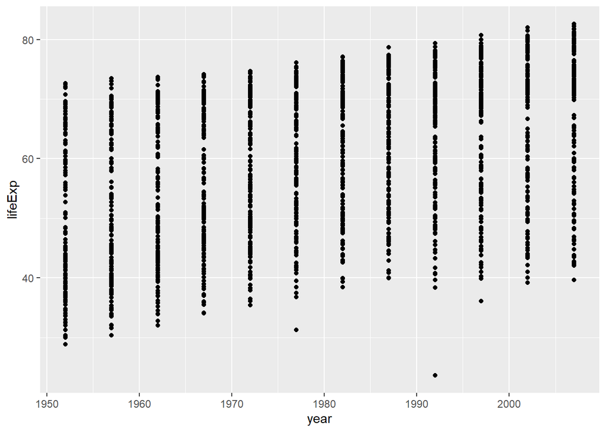

```r
ggplot(data = gapminder, mapping = aes(x = year, y = lifeExp)) +
  geom_point()
```

### 3b. Try to add color.

There is a color argument for the aes function  
You can can tell ggplot to color by continent

**Solution**

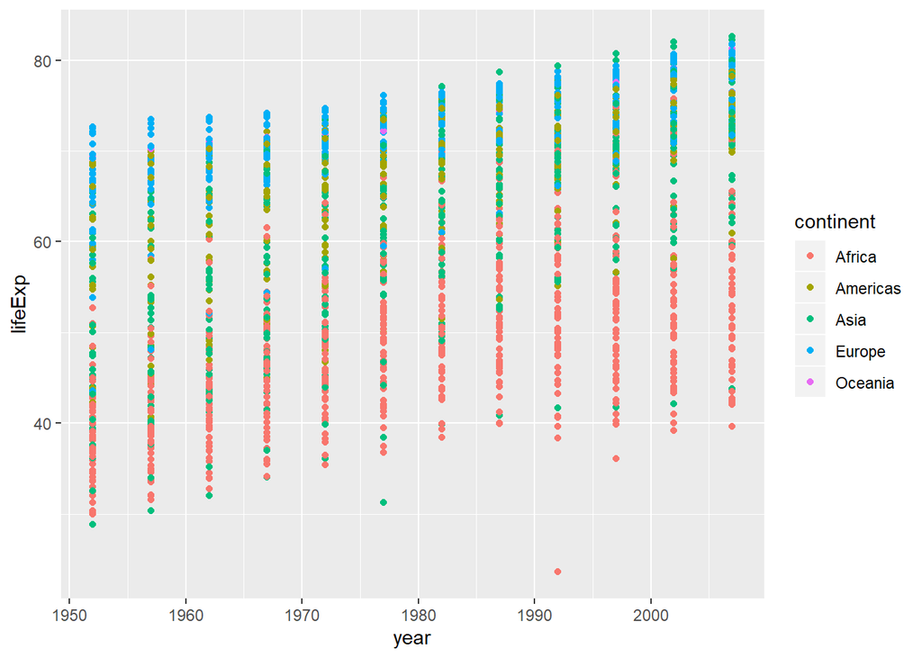

```r
ggplot(data = gapminder, mapping = aes(x = year, y = lifeExp, color = continent)) +
  geom_point()
```

### 3c. Switch the order of the geom_ functions. What happened?

**Solution**

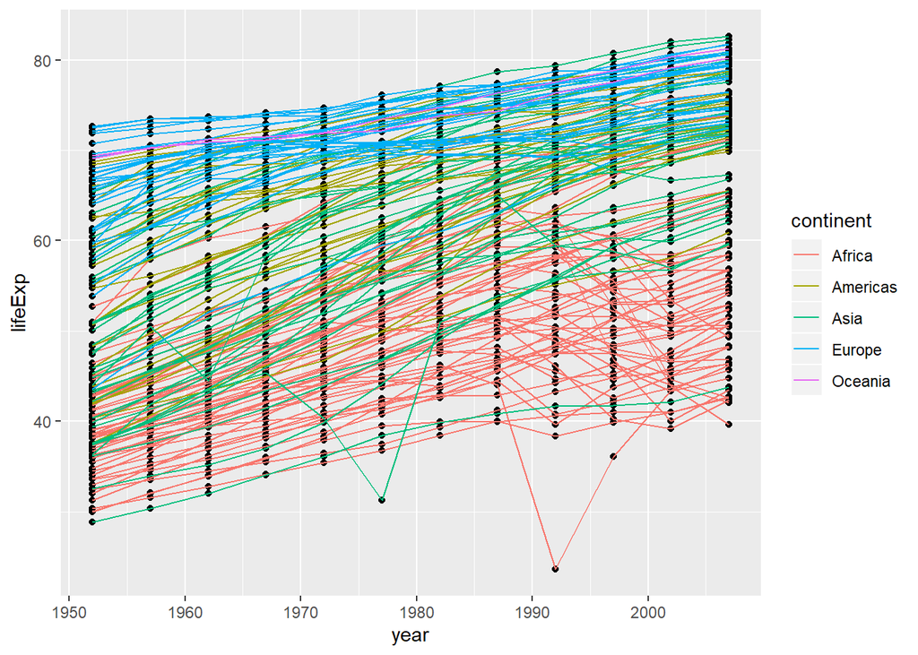

```r
ggplot(data = gapminder, mapping = aes(x=year, y=lifeExp, by=country)) +
  geom_point() + geom_line(mapping = aes(color=continent))
```

### 3d. Change the color and size of the points outside of aes.

Note: ?geom_point

**Solution**

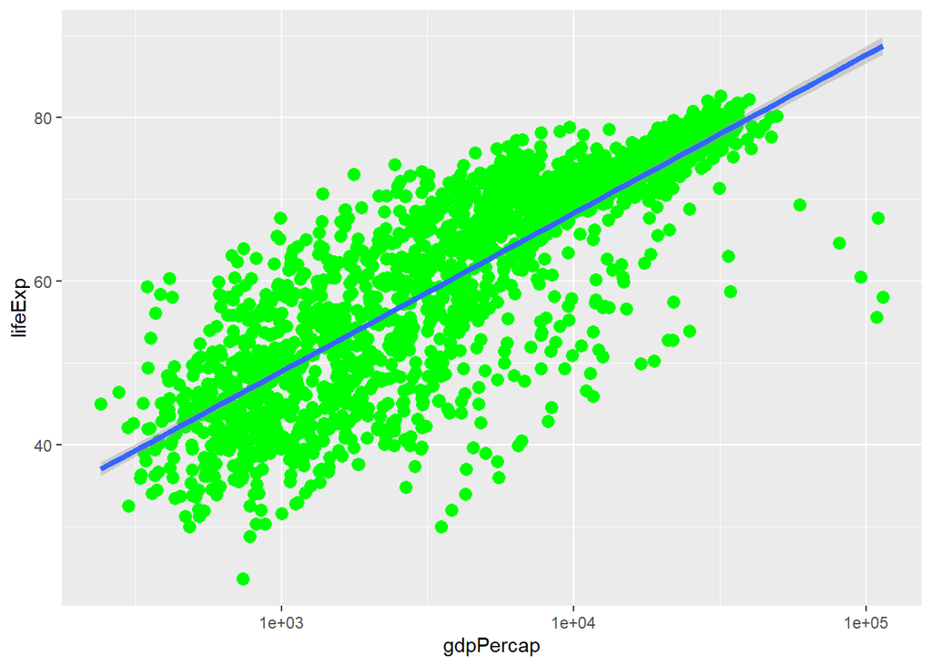

```r
ggplot(data = gapminder, mapping = aes(x = gdpPercap, y = lifeExp)) +
  geom_point(size=3, color="green") + scale_x_log10() +
  geom_smooth(method="lm", size=1.5)
```

### 3e. Now change the shape of the points and color the points by the continent

Note: You’ll get multiple linear model fits  
Note: ?geom_point

**Solution**

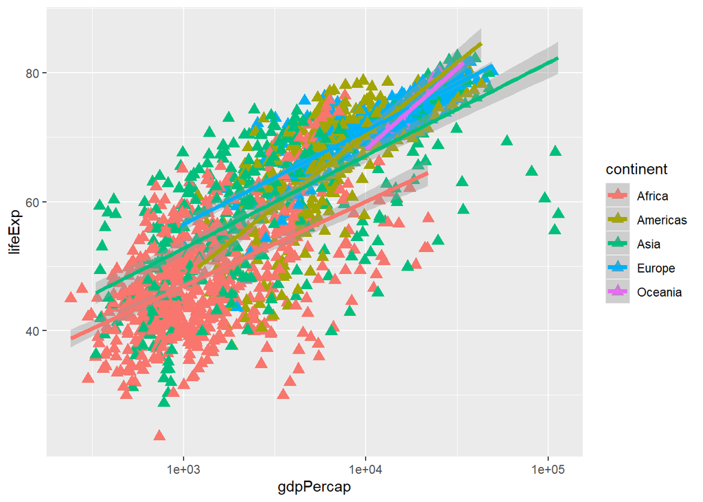

```r
ggplot(data = gapminder, mapping = aes(x = gdpPercap, y = lifeExp, color = continent)) +
  geom_point(size=3, shape=17) + scale_x_log10() +
  geom_smooth(method="lm", size=1.5)
```

### 3f. Create a density plot of GDP per capita, filled by continent.

Advanced: Transform the x axis to better visualise the data spread.  
Add a facet layer to panel the density plots by year.

**Solution**

Answer:

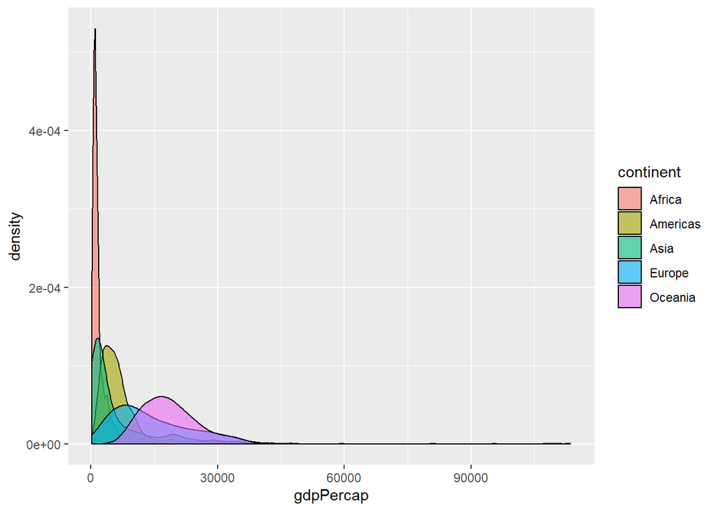

```r
ggplot(data = gapminder, mapping = aes(x = gdpPercap, fill=continent)) +
  geom_density(alpha=0.6)# + facet_wrap( ~ year) + scale_x_log10()
```

Advanced answer:

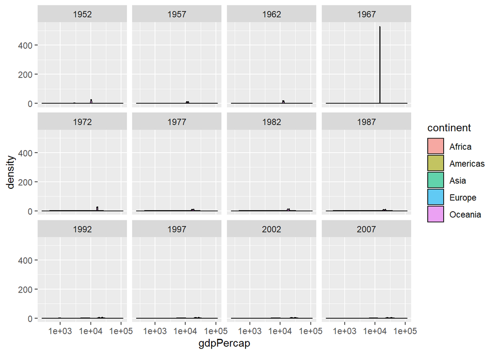

```r
ggplot(data = gapminder, mapping = aes(x = gdpPercap, fill=continent)) +
  geom_density(alpha=0.6) + facet_wrap( ~ year) + scale_x_log10()
```

# Exercise 3: loops

### Write a script that loops through the gapminder data by continent and prints out whether the mean life expectancy is smaller or larger than 50 years.

**Solution**

```r
meanLifeExp <- mean(gapminder$lifeExp)

for(cont in unique(gapminder$continent)){
  if(mean(gapminder[gapminder$continent == cont, 'lifeExp']) > meanLifeExp){
    print(paste(cont, 'lifeExp is above average'))
  }
  else if (mean(gapminder[gapminder$continent == cont, 'lifeExp']) < meanLifeExp){
    print(paste(cont, 'lifeExp if below average'))
  }
  else{
    print(paste(cont, 'lifeExp is average'))
  }
}
```

```
## [1] "Asia lifeExp is above average"
## [1] "Europe lifeExp is above average"
## [1] "Africa lifeExp if below average"
## [1] "Americas lifeExp is above average"
## [1] "Oceania lifeExp is above average"
```

# Exercise 4: Dplyr

#### 4a. Write a single command (which can span multiple lines and includes pipes) that will produce a dataframe that has the African values for lifeExp, country and year, but not for other Continents. How many rows does your dataframe have and why?

**Solution**

```r
year_country_lifeExp_Africa <- gapminder %>%
  filter(continent == "Africa") %>%
  select(year, country, lifeExp)
head(year_country_lifeExp_Africa)
```

|  | year | country | lifeExp |
| --- | --- | --- | --- |
| 1 | 1952 | Algeria | 43.077 |
| 2 | 1957 | Algeria | 45.685 |
| 3 | 1962 | Algeria | 48.303 |
| 4 | 1967 | Algeria | 51.407 |
| 5 | 1972 | Algeria | 54.518 |
| 6 | 1977 | Algeria | 58.014 |

#### 4b. Create a new dataframe that contains the minimum (MinExp) and maximum (MaxExp) life expectancies for each country.

**Solution**

```r
MinMaxExp <- gapminder %>%
  group_by(country) %>%
  summarize(MinExp = min(lifeExp),
            MaxExp = max(lifeExp))

head(MinMaxExp)
```

| country | MinExp | MaxExp |
| --- | --- | --- |
| Afghanistan | 28.801 | 43.828 |
| Albania | 55.230 | 76.423 |
| Algeria | 43.077 | 72.301 |
| Angola | 30.015 | 42.731 |
| Argentina | 62.485 | 75.320 |
| Australia | 69.120 | 81.235 |

#### 4c. Calculate the average life expectancy per country. Which has the longest average life expectancy and which has the shortest average life expectancy?

**Solution**

```r
gapminder %>%
  group_by(country) %>%
  summarize(mean_lifeExp = mean(lifeExp)) %>%
  filter(mean_lifeExp == min(mean_lifeExp) | mean_lifeExp == max(mean_lifeExp))
```

| country | mean_lifeExp |
| --- | --- |
| Iceland | 76.51142 |
| Sierra Leone | 36.76917 |